# Problem Statement:

#### A research laboratory was developing a new compound for the relief of severe cases of hay fever. In an experiment with 36 volunteers, the amounts of the two active ingredients (A & B) in the compound were varied at three levels each. Randomization was used in assigning four volunteers to each of the nine treatments. The data on hours of relief follow.

```python
import pandas as pd
import numpy as np
import matplotlib.pyplot as plt
import seaborn as sns
%matplotlib inline

from sklearn.metrics import mean_absolute_error
from sklearn.preprocessing import StandardScaler
%matplotlib inline
%config InlineBackend.figure_format = 'retina'

import statsmodels.api as sm
from statsmodels.formula.api import ols
import warnings
warnings.filterwarnings("ignore")
```

```python
data = pd.read_csv('Fever.csv')
data.head()
```

|  | A | B | Volunteer | Relief |
| --- | --- | --- | --- | --- |
| 0 | 1 | 1 | 1 | 2.4 |
| 1 | 1 | 1 | 2 | 2.7 |
| 2 | 1 | 1 | 3 | 2.3 |
| 3 | 1 | 1 | 4 | 2.5 |
| 4 | 1 | 2 | 1 | 4.6 |

### Let us check the types of variables in the data frame

```python
data.dtypes
```

```
A              int64
B              int64
Volunteer      int64
Relief       float64
dtype: object
```

```python
# get column names of data frame in a list
col_names = ['A','B','Volunteer']
print("\nNames of dataframe columns")
print(col_names)
```

```
Names of dataframe columns
['A', 'B', 'Volunteer']
```

```python
for col in col_names:
    data[col] = data[col].astype('category',copy=False)
```

# 4) Analyse the effects of one variable on another with the help of an interaction plot. What is an interaction between two treatments?

###### [hint: use the ‘pointplot’ function from the ‘seaborn’ graphical subroutine in Python]

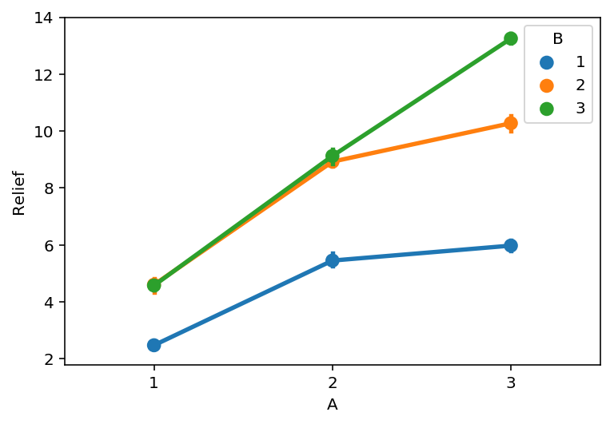

```python
sns.pointplot(x='A',y='Relief',hue='B',data=data)
plt.show()
```

Interaction effects occur when the effect of one variable depends on the value of another variable. Interaction effects are common in regression analysis, ANOVA, etc. Interaction effects indicate that a third variable influences the relationship between an independent and dependent variable. This type of effect makes the model more complex, but if the real world behaves this way, it is critical to incorporate it in your model. In this case, Relief is the outcome which changes according to the levels of 2 ingredients A & B.